# Module 82

#### Hemi-module gene counts:

603 probesets in hemi-module A.  
36 probesets in hemi-module B.  
Note: While the mapping of probesets to genes is usually one-to-one, some genes are targeted by multiple probesets, some probesets target multiple genes, and some probesets do not target any genes (i.e., the region of the genome they match is no longer considered genic).

#### Contrast SVE:

Signed variance explained (SVE) provides an indication of how similar a set of fold changes are to a gene module’s weight vector. An SVE value of 0.3, for example, indicates that 30% of the variance explained by the entire module set is accounted for by the module in question. Shown here are the SVE values for this module across a compendium of fold changes (contrasts). Extreme SVE values (e.g., > 0.05) indicate that those contrasts specifically induce (orange dots) or specifically repress (blue dots) this module. Examining the experimental conditions being compared in such contrasts (see tables below the figure) may provide insight into the gene module’s function.

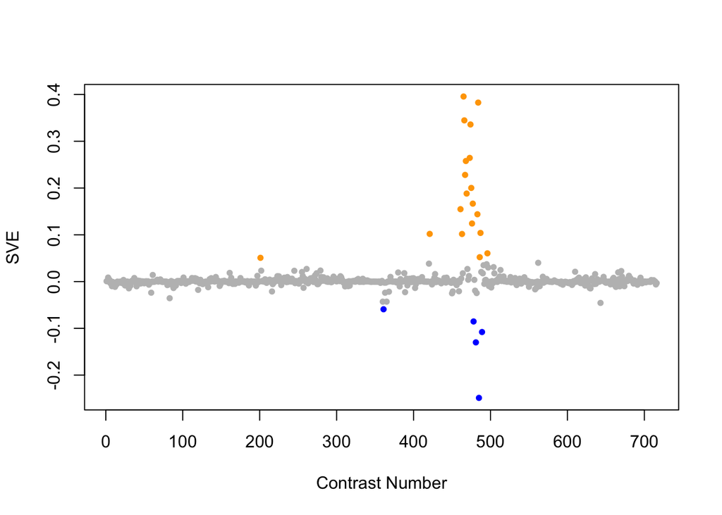

Positive SVE Contrasts:

|  | Contrast.Num | SVE | GEO.GSE | Cond.1 | Cond.2 | Mutation |
| --- | --- | --- | --- | --- | --- | --- |
| GSE23528A.s1t5.vs.s0t5 | 465 | 0.40 | GSE23528 | Adult at T18 in LD, time-series experiment 3 | Adult at T18, non-entrained control time-series experiment 4 |  |
| GSE23528A.s0t4.vs.s0t1 | 484 | 0.38 | GSE23528 | Adult at T14, non-entrained control time-series experiment 4 | Adult at T2, non-entrained control time-series experiment 4 |  |
| GSE23528A.s2t5.vs.s0t5 | 466 | 0.34 | GSE23528 | Adult at T18 in WC, time-series experiment 1 | Adult at T18, non-entrained control time-series experiment 4 |  |
| GSE23528A.s1t4.vs.s1t1 | 474 | 0.34 | GSE23528 | Adult at T14 in LD, time-series experiment 3 | Adult at T2 in LD, time-series experiment 3 |  |
| GSE23528A.s1t3.vs.s1t1 | 473 | 0.26 | GSE23528 | Adult at T10 in LD, time-series experiment 3 | Adult at T2 in LD, time-series experiment 3 |  |
| GSE23528A.s2t1.vs.s0t1 | 468 | 0.26 | GSE23528 | Adult at T2 in WC, time-series experiment 1 | Adult at T2, non-entrained control time-series experiment 4 |  |
| GSE23528A.s1t1.vs.s0t1 | 467 | 0.23 | GSE23528 | Adult at T2 in LD, time-series experiment 3 | Adult at T2, non-entrained control time-series experiment 4 |  |
| GSE23528A.s1t5.vs.s1t1 | 475 | 0.20 | GSE23528 | Adult at T18 in LD, time-series experiment 3 | Adult at T2 in LD, time-series experiment 3 |  |
| GSE23528A.s1t6.vs.s0t6 | 469 | 0.19 | GSE23528 | Adult at T22 in LD, time-series experiment 3 | Adult at T22, non-entrained control time-series experiment 4 |  |
| GSE23528A.s1t2.vs.s1t1 | 477 | 0.17 | GSE23528 | Adult at T6 in LD, time-series experiment 3 | Adult at T2 in LD, time-series experiment 3 |  |
| GSE23528A.s1t3.vs.s0t3 | 461 | 0.15 | GSE23528 | Adult at T10 in LD, time-series experiment 3 | Adult at T10, non-entrained control time-series experiment 4 |  |
| GSE23528A.s0t3.vs.s0t1 | 483 | 0.14 | GSE23528 | Adult at T10, non-entrained control time-series experiment 4 | Adult at T2, non-entrained control time-series experiment 4 |  |
| GSE23528A.s1t6.vs.s1t1 | 476 | 0.12 | GSE23528 | Adult at T22 in LD, time-series experiment 3 | Adult at T2 in LD, time-series experiment 3 |  |
| GSE23528A.s0t2.vs.s0t1 | 487 | 0.10 | GSE23528 | Adult at T6, non-entrained control time-series experiment 4 | Adult at T2, non-entrained control time-series experiment 4 |  |
| GSE28494.s1t2.vs.s0t2 | 421 | 0.10 | GSE28494 | lin-54(n3423) dissected germline 1 | wild-type N2 dissected germline 1 | lin-54 |
| GSE23528A.s1t4.vs.s0t4 | 463 | 0.10 | GSE23528 | Adult at T14 in LD, time-series experiment 3 | Adult at T14, non-entrained control time-series experiment 4 |  |
| GSE23528C.s1t5.vs.s1t1 | 496 | 0.06 | GSE23528 | Adult at T42 in DD, time-series experiment 2 | Adult at T26 in DD, time-series experiment 2 |  |
| GSE23528A.s0t6.vs.s0t1 | 486 | 0.05 | GSE23528 | Adult at T22, non-entrained control time-series experiment 4 | Adult at T2, non-entrained control time-series experiment 4 |  |
| GSE43959.s3t2.vs.s3t1 | 201 | 0.05 | GSE43959 | N2 gravid adult on Comamonas DA1877 rep 1 | N2 young adult on Comamonas DA1877 rep 1 |  |

Negative SVE Contrasts:

|  | Contrast.Num | SVE | GEO.GSE | Cond.1 | Cond.2 | Mutation |
| --- | --- | --- | --- | --- | --- | --- |
| GSE23528A.s0t5.vs.s0t1 | 485 | -0.25 | GSE23528 | Adult at T18, non-entrained control time-series experiment 4 | Adult at T2, non-entrained control time-series experiment 4 |  |
| GSE23528A.s2t6.vs.s2t1 | 481 | -0.13 | GSE23528 | Adult at T22 in WC, time-series experiment 1 | Adult at T2 in WC, time-series experiment 1 |  |
| GSE23528B.s1t3.vs.s1t1 | 489 | -0.11 | GSE23528 | Adult at T34 in CC, time-series experiment 3 | Adult at T26 in CC, time-series experiment 3 |  |
| GSE23528A.s2t3.vs.s2t1 | 478 | -0.09 | GSE23528 | Adult at T10 in WC, time-series experiment 1 | Adult at T2 in WC, time-series experiment 1 |  |
| GSE37432.s2t1.vs.s0t1 | 361 | -0.06 | GSE37432 | piwi n4503 nDf57 rep1 | N2 rep1 | prg-1;prg-2 |

$~$

#### Contrast SVE, Up-Regulated Genes Only:

Calculating SVE for up-regulated and down-regulated genes separately may be more informative in many cases than projecting the up- and down- gene sets together. This is due to the fact that the weight distribution of many modules is highly skewed, indicating that only one of the hemi-modules may be biologically meaningful (i.e., a set of genes are strongly correlated by only a few genes (or none) are strongly anti-correlated to that set.)

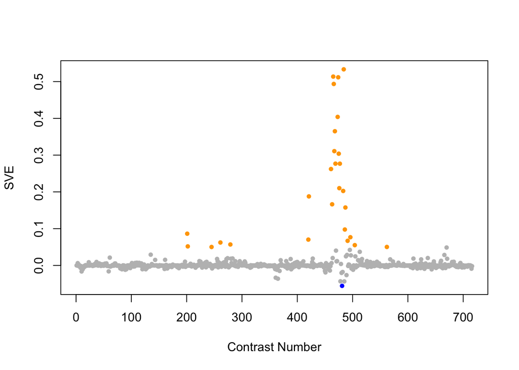

Positive SVE Contrasts:

|  | Contrast.Num | SVE | GEO.GSE | Cond.1 | Cond.2 | Mutation |
| --- | --- | --- | --- | --- | --- | --- |
| GSE23528A.s0t4.vs.s0t1 | 484 | 0.53 | GSE23528 | Adult at T14, non-entrained control time-series experiment 4 | Adult at T2, non-entrained control time-series experiment 4 |  |
| GSE23528A.s1t5.vs.s0t5 | 465 | 0.51 | GSE23528 | Adult at T18 in LD, time-series experiment 3 | Adult at T18, non-entrained control time-series experiment 4 |  |
| GSE23528A.s1t4.vs.s1t1 | 474 | 0.51 | GSE23528 | Adult at T14 in LD, time-series experiment 3 | Adult at T2 in LD, time-series experiment 3 |  |
| GSE23528A.s2t5.vs.s0t5 | 466 | 0.49 | GSE23528 | Adult at T18 in WC, time-series experiment 1 | Adult at T18, non-entrained control time-series experiment 4 |  |
| GSE23528A.s1t3.vs.s1t1 | 473 | 0.40 | GSE23528 | Adult at T10 in LD, time-series experiment 3 | Adult at T2 in LD, time-series experiment 3 |  |
| GSE23528A.s2t1.vs.s0t1 | 468 | 0.37 | GSE23528 | Adult at T2 in WC, time-series experiment 1 | Adult at T2, non-entrained control time-series experiment 4 |  |
| GSE23528A.s1t1.vs.s0t1 | 467 | 0.31 | GSE23528 | Adult at T2 in LD, time-series experiment 3 | Adult at T2, non-entrained control time-series experiment 4 |  |
| GSE23528A.s1t5.vs.s1t1 | 475 | 0.30 | GSE23528 | Adult at T18 in LD, time-series experiment 3 | Adult at T2 in LD, time-series experiment 3 |  |
| GSE23528A.s1t6.vs.s0t6 | 469 | 0.28 | GSE23528 | Adult at T22 in LD, time-series experiment 3 | Adult at T22, non-entrained control time-series experiment 4 |  |
| GSE23528A.s1t2.vs.s1t1 | 477 | 0.28 | GSE23528 | Adult at T6 in LD, time-series experiment 3 | Adult at T2 in LD, time-series experiment 3 |  |
| GSE23528A.s1t3.vs.s0t3 | 461 | 0.26 | GSE23528 | Adult at T10 in LD, time-series experiment 3 | Adult at T10, non-entrained control time-series experiment 4 |  |
| GSE23528A.s1t6.vs.s1t1 | 476 | 0.21 | GSE23528 | Adult at T22 in LD, time-series experiment 3 | Adult at T2 in LD, time-series experiment 3 |  |
| GSE23528A.s0t3.vs.s0t1 | 483 | 0.20 | GSE23528 | Adult at T10, non-entrained control time-series experiment 4 | Adult at T2, non-entrained control time-series experiment 4 |  |
| GSE28494.s1t2.vs.s0t2 | 421 | 0.19 | GSE28494 | lin-54(n3423) dissected germline 1 | wild-type N2 dissected germline 1 | lin-54 |
| GSE23528A.s1t4.vs.s0t4 | 463 | 0.17 | GSE23528 | Adult at T14 in LD, time-series experiment 3 | Adult at T14, non-entrained control time-series experiment 4 |  |
| GSE23528A.s0t2.vs.s0t1 | 487 | 0.16 | GSE23528 | Adult at T6, non-entrained control time-series experiment 4 | Adult at T2, non-entrained control time-series experiment 4 |  |
| GSE23528A.s0t6.vs.s0t1 | 486 | 0.10 | GSE23528 | Adult at T22, non-entrained control time-series experiment 4 | Adult at T2, non-entrained control time-series experiment 4 |  |
| GSE43959.s3t2.vs.s3t1 | 201 | 0.09 | GSE43959 | N2 gravid adult on Comamonas DA1877 rep 1 | N2 young adult on Comamonas DA1877 rep 1 |  |
| GSE23528C.s1t5.vs.s1t1 | 496 | 0.08 | GSE23528 | Adult at T42 in DD, time-series experiment 2 | Adult at T26 in DD, time-series experiment 2 |  |
| GSE28494.s1t1.vs.s0t1 | 420 | 0.07 | GSE28494 | lin-54(n2990) embryo 1 | wild-type N2 embryo 1 | lin-54 |
| GSE23528B.s1t5.vs.s1t1 | 491 | 0.07 | GSE23528 | Adult at T42 in CC, time-series experiment 3 | Adult at T26 in CC, time-series experiment 3 |  |
| GSE41366A.s1t4.vs.s0t4 | 261 | 0.06 | GSE41366 | low_DDVP-2h_expose-26h_harvest-rep1 | control-2h_expose-26h_harvest-rep1 |  |
| GSE41366B.s0t2.vs.s0t1 | 279 | 0.06 | GSE41366 | control-8h_expose-20h_harvest-rep1 | control-8h_expose-14h_harvest-rep1 |  |
| GSE22660.s0t2.vs.s0t1 | 504 | 0.06 | GSE22660 | 1ug/ml DMSO control, biological rep 1 | 100ng/ml DMSO control, biological rep 1 |  |
| GSE43959.s1t2.vs.s1t1 | 202 | 0.05 | GSE43959 | N2 gravid adult on E. coli OP50 rep 1 | N2 young adult on E. coli OP50 rep 1 |  |
| GSE2180.s4t5.vs.s3t5 | 562 | 0.05 | GSE2180 | pp66-1 | p66-1 | pal-1(RNAi) |
| GSE42592C.s3t3.vs.s3t2 | 245 | 0.05 | GSE42592 | mercury_high_expose-8h_rep1 | mercury_high_expose-4h_rep1 |  |

Negative SVE Contrasts:

|  | Contrast.Num | SVE | GEO.GSE | Cond.1 | Cond.2 | Mutation |
| --- | --- | --- | --- | --- | --- | --- |
| GSE23528A.s2t6.vs.s2t1 | 481 | -0.06 | GSE23528 | Adult at T22 in WC, time-series experiment 1 | Adult at T2 in WC, time-series experiment 1 |  |
| GSE23528A.s0t5.vs.s0t1 | 485 | -0.04 | GSE23528 | Adult at T18, non-entrained control time-series experiment 4 | Adult at T2, non-entrained control time-series experiment 4 |  |
| GSE23528A.s2t3.vs.s2t1 | 478 | -0.04 | GSE23528 | Adult at T10 in WC, time-series experiment 1 | Adult at T2 in WC, time-series experiment 1 |  |
| GSE36358.s3t1.vs.s0t1 | 365 | -0.04 | GSE36358 | Hyper Gravity | Ground Control (Tsukuba space center) |  |
| GSE37432.s2t1.vs.s0t1 | 361 | -0.03 | GSE37432 | piwi n4503 nDf57 rep1 | N2 rep1 | prg-1;prg-2 |

$~$

#### Contrast SVE, Down-Regulated Genes Only:

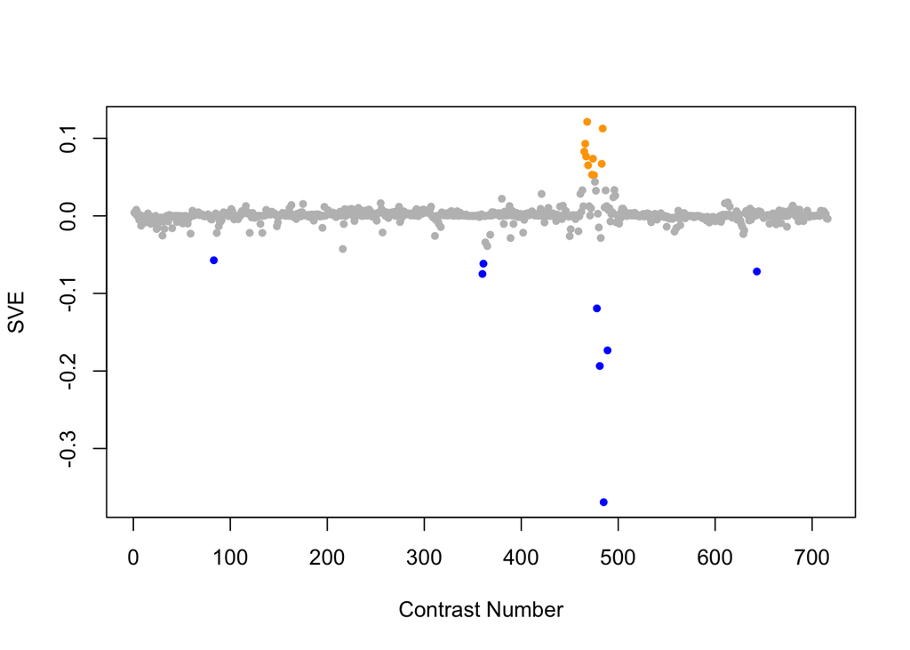

Positive SVE Contrasts:

|  | Contrast.Num | SVE | GEO.GSE | Cond.1 | Cond.2 | Mutation |
| --- | --- | --- | --- | --- | --- | --- |
| GSE23528A.s2t1.vs.s0t1 | 468 | 0.12 | GSE23528 | Adult at T2 in WC, time-series experiment 1 | Adult at T2, non-entrained control time-series experiment 4 |  |
| GSE23528A.s0t4.vs.s0t1 | 484 | 0.11 | GSE23528 | Adult at T14, non-entrained control time-series experiment 4 | Adult at T2, non-entrained control time-series experiment 4 |  |
| GSE23528A.s2t5.vs.s0t5 | 466 | 0.09 | GSE23528 | Adult at T18 in WC, time-series experiment 1 | Adult at T18, non-entrained control time-series experiment 4 |  |
| GSE23528A.s1t5.vs.s0t5 | 465 | 0.08 | GSE23528 | Adult at T18 in LD, time-series experiment 3 | Adult at T18, non-entrained control time-series experiment 4 |  |
| GSE23528A.s1t1.vs.s0t1 | 467 | 0.08 | GSE23528 | Adult at T2 in LD, time-series experiment 3 | Adult at T2, non-entrained control time-series experiment 4 |  |
| GSE23528A.s1t4.vs.s1t1 | 474 | 0.07 | GSE23528 | Adult at T14 in LD, time-series experiment 3 | Adult at T2 in LD, time-series experiment 3 |  |
| GSE23528A.s0t3.vs.s0t1 | 483 | 0.07 | GSE23528 | Adult at T10, non-entrained control time-series experiment 4 | Adult at T2, non-entrained control time-series experiment 4 |  |
| GSE23528A.s1t6.vs.s0t6 | 469 | 0.07 | GSE23528 | Adult at T22 in LD, time-series experiment 3 | Adult at T22, non-entrained control time-series experiment 4 |  |
| GSE23528A.s1t3.vs.s1t1 | 473 | 0.05 | GSE23528 | Adult at T10 in LD, time-series experiment 3 | Adult at T2 in LD, time-series experiment 3 |  |
| GSE23528A.s1t5.vs.s1t1 | 475 | 0.05 | GSE23528 | Adult at T18 in LD, time-series experiment 3 | Adult at T2 in LD, time-series experiment 3 |  |

Negative SVE Contrasts:

|  | Contrast.Num | SVE | GEO.GSE | Cond.1 | Cond.2 | Mutation |
| --- | --- | --- | --- | --- | --- | --- |
| GSE23528A.s0t5.vs.s0t1 | 485 | -0.37 | GSE23528 | Adult at T18, non-entrained control time-series experiment 4 | Adult at T2, non-entrained control time-series experiment 4 |  |
| GSE23528A.s2t6.vs.s2t1 | 481 | -0.19 | GSE23528 | Adult at T22 in WC, time-series experiment 1 | Adult at T2 in WC, time-series experiment 1 |  |
| GSE23528B.s1t3.vs.s1t1 | 489 | -0.17 | GSE23528 | Adult at T34 in CC, time-series experiment 3 | Adult at T26 in CC, time-series experiment 3 |  |
| GSE23528A.s2t3.vs.s2t1 | 478 | -0.12 | GSE23528 | Adult at T10 in WC, time-series experiment 1 | Adult at T2 in WC, time-series experiment 1 |  |
| GSE37432.s1t1.vs.s0t1 | 360 | -0.07 | GSE37432 | piwi n4357 n4358 rep1 | N2 rep1 | prg-1;prg-2 |
| GSE16975.s1t1.vs.s0t1 | 643 | -0.07 | GSE16975 | C.elegans hydrogen sulfide sample replicate 1 | C.elegans control sample replicate 1 |  |
| GSE37432.s2t1.vs.s0t1 | 361 | -0.06 | GSE37432 | piwi n4503 nDf57 rep1 | N2 rep1 | prg-1;prg-2 |
| GSE6563.s1t1.vs.s0t1 | 83 | -0.06 | GSE6563 | daf19(m86)_daf12(sa204) replicate 1 | daf19(WT)_daf12(sa204) replicate 1 | daf-19 |

$~$

$~$

#### GO Term Enrichment:

This analysis tests each hemi-module for enrichment of specific GO terms. Only gene-level annotations (e.g., as would be found on the gene’s page in Wormbase) are tested - the hierarchical structure of the GO ontology is not taken into account.

*Note: At least the top two most enriched terms from each GO domain (BP/MF/CC) are shown, even when not statistically significant.*

##### Enriched GO terms: Hemi-module A

| ID | GO.Term | GO Domain | Raw p-value | Adj p-value |
| --- | --- | --- | --- | --- |
| [GO_0006281](http://amigo.geneontology.org/amigo/term/GO:0006281) | DNA repair | BP | 1.16e-08 | 4.24e-05 |
| [GO_0006974](http://amigo.geneontology.org/amigo/term/GO:0006974) | cellular response to DNA damage stimulus | BP | 8.20e-07 | 1.49e-03 |
| [GO_0007186](http://amigo.geneontology.org/amigo/term/GO:0007186) | G protein-coupled receptor signaling pathway | BP | 2.13e-06 | 2.59e-03 |
| [GO_0006364](http://amigo.geneontology.org/amigo/term/GO:0006364) | rRNA processing | BP | 1.01e-05 | 8.04e-03 |
| [GO_0007034](http://amigo.geneontology.org/amigo/term/GO:0007034) | vacuolar transport | BP | 1.10e-05 | 8.04e-03 |
| [GO_0055085](http://amigo.geneontology.org/amigo/term/GO:0055085) | transmembrane transport | BP | 1.93e-05 | 1.17e-02 |
| [GO_0000398](http://amigo.geneontology.org/amigo/term/GO:0000398) | mRNA splicing, via spliceosome | BP | 4.25e-05 | 2.21e-02 |
| [GO_0000447](http://amigo.geneontology.org/amigo/term/GO:0000447) | endonucleolytic cleavage in ITS1 to separate SSU-rRNA from 5.8S rRNA and LSU-rRNA from tricistronic rRNA transcript (SSU-rRNA, 5.8S rRNA, LSU-rRNA) | BP | 1.16e-04 | 5.26e-02 |
| [GO_0003676](http://amigo.geneontology.org/amigo/term/GO:0003676) | nucleic acid binding | MF | 2.15e-09 | 4.40e-06 |
| [GO_0005484](http://amigo.geneontology.org/amigo/term/GO:0005484) | SNAP receptor activity | MF | 6.48e-05 | 6.61e-02 |
| [GO_0035064](http://amigo.geneontology.org/amigo/term/GO:0035064) | methylated histone binding | MF | 1.65e-04 | 9.20e-02 |
| [GO_0000149](http://amigo.geneontology.org/amigo/term/GO:0000149) | SNARE binding | MF | 1.80e-04 | 9.20e-02 |
| [GO_0003682](http://amigo.geneontology.org/amigo/term/GO:0003682) | chromatin binding | MF | 2.36e-04 | 9.50e-02 |
| [GO_0003723](http://amigo.geneontology.org/amigo/term/GO:0003723) | RNA binding | MF | 2.79e-04 | 9.50e-02 |
| [GO_0016021](http://amigo.geneontology.org/amigo/term/GO:0016021) | integral component of membrane | CC | 7.19e-39 | 3.50e-36 |
| [GO_0016020](http://amigo.geneontology.org/amigo/term/GO:0016020) | membrane | CC | 7.55e-39 | 3.50e-36 |
| [GO_0005730](http://amigo.geneontology.org/amigo/term/GO:0005730) | nucleolus | CC | 1.34e-18 | 4.13e-16 |
| [GO_0005634](http://amigo.geneontology.org/amigo/term/GO:0005634) | nucleus | CC | 3.53e-16 | 8.19e-14 |
| [GO_0005887](http://amigo.geneontology.org/amigo/term/GO:0005887) | integral component of plasma membrane | CC | 1.18e-06 | 2.20e-04 |
| [GO_0005886](http://amigo.geneontology.org/amigo/term/GO:0005886) | plasma membrane | CC | 2.42e-06 | 3.75e-04 |
| [GO_0032040](http://amigo.geneontology.org/amigo/term/GO:0032040) | small-subunit processome | CC | 8.26e-05 | 1.09e-02 |
| [GO_0031262](http://amigo.geneontology.org/amigo/term/GO:0031262) | Ndc80 complex | CC | 1.16e-04 | 1.34e-02 |
| [GO_0005681](http://amigo.geneontology.org/amigo/term/GO:0005681) | spliceosomal complex | CC | 1.43e-04 | 1.48e-02 |
| [GO_0031201](http://amigo.geneontology.org/amigo/term/GO:0031201) | SNARE complex | CC | 2.94e-04 | 2.73e-02 |
| [GO_0016592](http://amigo.geneontology.org/amigo/term/GO:0016592) | mediator complex | CC | 3.76e-04 | 2.91e-02 |
| [GO_0030687](http://amigo.geneontology.org/amigo/term/GO:0030687) | preribosome, large subunit precursor | CC | 3.76e-04 | 2.91e-02 |
| [GO_0030915](http://amigo.geneontology.org/amigo/term/GO:0030915) | Smc5-Smc6 complex | CC | 5.51e-04 | 3.94e-02 |
| [GO_0005737](http://amigo.geneontology.org/amigo/term/GO:0005737) | cytoplasm | CC | 6.32e-04 | 4.19e-02 |
| [GO_0005694](http://amigo.geneontology.org/amigo/term/GO:0005694) | chromosome | CC | 7.09e-04 | 4.38e-02 |
| [GO_0033553](http://amigo.geneontology.org/amigo/term/GO:0033553) | rDNA heterochromatin | CC | 9.59e-04 | 5.23e-02 |
| [GO_0070390](http://amigo.geneontology.org/amigo/term/GO:0070390) | transcription export complex 2 | CC | 9.59e-04 | 5.23e-02 |
| [GO_0000784](http://amigo.geneontology.org/amigo/term/GO:0000784) | nuclear chromosome, telomeric region | CC | 1.57e-03 | 8.09e-02 |
| [GO_0046540](http://amigo.geneontology.org/amigo/term/GO:0046540) | U4/U6 x U5 tri-snRNP complex | CC | 1.97e-03 | 9.62e-02 |

##### Enriched GO terms: Hemi-module B

| ID | GO.Term | GO Domain | Raw p-value | Adj p-value |
| --- | --- | --- | --- | --- |
| [GO_0006606](http://amigo.geneontology.org/amigo/term/GO:0006606) | protein import into nucleus | BP | 1.71e-03 | 1.00e+00 |
| [GO_0043985](http://amigo.geneontology.org/amigo/term/GO:0043985) | histone H4-R3 methylation | BP | 1.99e-03 | 1.00e+00 |
| [GO_0016277](http://amigo.geneontology.org/amigo/term/GO:0016277) | [myelin basic protein]-arginine N-methyltransferase activity | MF | 1.99e-03 | 1.00e+00 |
| [GO_0044020](http://amigo.geneontology.org/amigo/term/GO:0044020) | histone methyltransferase activity (H4-R3 specific) | MF | 1.99e-03 | 1.00e+00 |
| [GO_0031080](http://amigo.geneontology.org/amigo/term/GO:0031080) | nuclear pore outer ring | CC | 1.19e-02 | 1.00e+00 |
| [GO_0031965](http://amigo.geneontology.org/amigo/term/GO:0031965) | nuclear membrane | CC | 5.06e-02 | 1.00e+00 |

$~$

$~$

#### Tissue Enrichment:

This analysis tests each hemi-module for enrichment of genes associated with anatomy terms. Negative enrichment scores indicate fewer hemi-module genes than expected by random chance were associated with the anatomy term in question.

##### Enriched tissues: Hemi-module A

No significant annotations.

##### Enriched tissues: Hemi-module B

| ID | Anatomy.Term | Definition | Raw p-value | Adj p-value |
| --- | --- | --- | --- | --- |
| [WBbt_0006899](https://wormbase.org/species/all/anatomy_term/WBbt:0006899) | P11.p | descendent cell of P11, posterior | 2.17e-04 | 7.12e-02 |
| [WBbt_0004149](https://wormbase.org/species/all/anatomy_term/WBbt:0004149) | hyp7 | Postembryonic large hypodermal syncytium, hermaphrodite | 3.14e-04 | 7.12e-02 |
| [WBbt_0004151](https://wormbase.org/species/all/anatomy_term/WBbt:0004151) | hyp7 | Postembryonic large hypodermal syncytium, hermaphrodite | 3.14e-04 | 7.12e-02 |
| [WBbt_0004153](https://wormbase.org/species/all/anatomy_term/WBbt:0004153) | hyp7 | Postembryonic large hypodermal syncytium, hermaphrodite | 3.14e-04 | 7.12e-02 |
| [WBbt_0004155](https://wormbase.org/species/all/anatomy_term/WBbt:0004155) | hyp7 | Postembryonic large hypodermal syncytium, hermaphrodite | 3.14e-04 | 7.12e-02 |
| [WBbt_0004145](https://wormbase.org/species/all/anatomy_term/WBbt:0004145) | hyp7 | Postembryonic large hypodermal syncytium, hermaphrodite | 3.41e-04 | 7.12e-02 |
| [WBbt_0004147](https://wormbase.org/species/all/anatomy_term/WBbt:0004147) | hyp7 | Postembryonic large hypodermal syncytium, hermaphrodite | 3.70e-04 | 7.12e-02 |
| [WBbt_0007253](https://wormbase.org/species/all/anatomy_term/WBbt:0007253) | P5.paa | post-embryonic cell of pedigree P5.paa | 4.94e-04 | 7.12e-02 |
| [WBbt_0007254](https://wormbase.org/species/all/anatomy_term/WBbt:0007254) | P5.pap | post-embryonic cell of pedigree P5.pap | 4.94e-04 | 7.12e-02 |
| [WBbt_0004477](https://wormbase.org/species/all/anatomy_term/WBbt:0004477) | vulval cell | Hermaphrodite vulva | 5.27e-04 | 7.12e-02 |
| [WBbt_0007252](https://wormbase.org/species/all/anatomy_term/WBbt:0007252) | P5.pa | post-embryonic cell of pedigree P5.pa | 5.27e-04 | 7.12e-02 |
| [WBbt_0007256](https://wormbase.org/species/all/anatomy_term/WBbt:0007256) | P5.ppa | post-embryonic cell of pedigree P5.ppa | 5.27e-04 | 7.12e-02 |
| [WBbt_0007265](https://wormbase.org/species/all/anatomy_term/WBbt:0007265) | P7.ppa | post-embryonic cell of pedigree P7.ppa | 5.27e-04 | 7.12e-02 |
| [WBbt_0007266](https://wormbase.org/species/all/anatomy_term/WBbt:0007266) | P7.ppp | post-embryonic cell of pedigree P7.ppp | 5.27e-04 | 7.12e-02 |
| [WBbt_0004448](https://wormbase.org/species/all/anatomy_term/WBbt:0004448) | vulval cell | Hermaphrodite vulva | 5.62e-04 | 7.12e-02 |
| [WBbt_0007255](https://wormbase.org/species/all/anatomy_term/WBbt:0007255) | P5.pp | post-embryonic cell of pedigree P5.pp | 5.62e-04 | 7.12e-02 |
| [WBbt_0007264](https://wormbase.org/species/all/anatomy_term/WBbt:0007264) | P7.pap | post-embryonic cell of pedigree P7.pap | 5.62e-04 | 7.12e-02 |
| [WBbt_0006984](https://wormbase.org/species/all/anatomy_term/WBbt:0006984) | P7.pp | cell, posterior descendent of P7.p | 6.35e-04 | 7.12e-02 |
| [WBbt_0006983](https://wormbase.org/species/all/anatomy_term/WBbt:0006983) | P7.pa | cell, anterior descendent of P7.p | 6.73e-04 | 7.12e-02 |
| [WBbt_0006989](https://wormbase.org/species/all/anatomy_term/WBbt:0006989) | P6.paa | cell, anterior daughter of P6.pa | 6.73e-04 | 7.12e-02 |
| [WBbt_0006990](https://wormbase.org/species/all/anatomy_term/WBbt:0006990) | P6.pap | cell, posterior daughter of P6.pa | 6.73e-04 | 7.12e-02 |
| [WBbt_0006991](https://wormbase.org/species/all/anatomy_term/WBbt:0006991) | P6.ppa | cell, anterior daughter of P6.pp | 6.73e-04 | 7.12e-02 |
| [WBbt_0007260](https://wormbase.org/species/all/anatomy_term/WBbt:0007260) | P6.ppp | post-embryonic cell of pedigree P6.ppp | 6.73e-04 | 7.12e-02 |
| [WBbt_0006987](https://wormbase.org/species/all/anatomy_term/WBbt:0006987) | P6.pa | cell, anterior daughter of P6.p | 7.53e-04 | 7.33e-02 |
| [WBbt_0006988](https://wormbase.org/species/all/anatomy_term/WBbt:0006988) | P6.pp | cell, posteior daughter of P6.p | 7.53e-04 | 7.33e-02 |

$~$

$~$

#### HOMER promoter motif enrichment:

This analysis tests each hemi-module for enrichment of 108 known *C. elegans* transcription factor binding site motifs (see [108 CE motifs](https://katiepod.github.io//all.worm.motifs.html)) using the HOMER (Hypergeometric Optimization of Motif EnRichment) software (see [PMID:20513432](https://pubmed.ncbi.nlm.nih.gov/20513432)). HOMER was run using default parameters on sequences 1 kb upstream of the transcription start site.

##### Motif enrichment: Hemi-module A

Total target sequences = 522  
Total background sequences = 39485  
* - possible false positive

Rank

Motif

P-value

log P-pvalue

% of Targets

% of Background

STD(Bg STD)

Best Match/Details

Motif File

1

[figure not shown]

1e-15

-3.567e+01

13.79%

4.58%

259.3bp (333.6bp)

PL0009.1_hlh-26/Jaspar(0.596)  
[More Information](https://katiepod.github.io/HomerResults/m82_a_hemi_genes.txt.out.1kb/homerResults/motif1.info.html) | [Similar Motifs Found](https://katiepod.github.io/HomerResults/m82_a_hemi_genes.txt.out.1kb/homerResults/motif1.similar.html)

[motif file (matrix)](https://katiepod.github.io/HomerResults/m82_a_hemi_genes.txt.out.1kb/homerResults/motif1.motif)

2

[figure not shown]

1e-13

-3.045e+01

4.79%

0.64%

297.6bp (327.0bp)

CES-1(Homeobox)/cElegans-L1-CES1-ChIP-Seq(modEncode)/Homer(0.684)  
[More Information](https://katiepod.github.io/HomerResults/m82_a_hemi_genes.txt.out.1kb/homerResults/motif2.info.html) | [Similar Motifs Found](https://katiepod.github.io/HomerResults/m82_a_hemi_genes.txt.out.1kb/homerResults/motif2.similar.html)

[motif file (matrix)](https://katiepod.github.io/HomerResults/m82_a_hemi_genes.txt.out.1kb/homerResults/motif2.motif)

3

[figure not shown]

1e-13

-3.032e+01

19.73%

9.01%

268.6bp (329.8bp)

EFL-1(E2F)/cElegans-L1-EFL1-ChIP-Seq(modEncode)/Homer(0.642)  
[More Information](https://katiepod.github.io/HomerResults/m82_a_hemi_genes.txt.out.1kb/homerResults/motif3.info.html) | [Similar Motifs Found](https://katiepod.github.io/HomerResults/m82_a_hemi_genes.txt.out.1kb/homerResults/motif3.similar.html)

[motif file (matrix)](https://katiepod.github.io/HomerResults/m82_a_hemi_genes.txt.out.1kb/homerResults/motif3.motif)

4

[figure not shown]

1e-12

-2.911e+01

4.60%

0.62%

316.4bp (319.4bp)

SD0001.1_at_AC_acceptor/Jaspar(0.543)  
[More Information](https://katiepod.github.io/HomerResults/m82_a_hemi_genes.txt.out.1kb/homerResults/motif4.info.html) | [Similar Motifs Found](https://katiepod.github.io/HomerResults/m82_a_hemi_genes.txt.out.1kb/homerResults/motif4.similar.html)

[motif file (matrix)](https://katiepod.github.io/HomerResults/m82_a_hemi_genes.txt.out.1kb/homerResults/motif4.motif)

5

[figure not shown]

1e-12

-2.893e+01

10.92%

3.56%

248.5bp (327.4bp)

ceh-48/MA0921.1/Jaspar(0.597)  
[More Information](https://katiepod.github.io/HomerResults/m82_a_hemi_genes.txt.out.1kb/homerResults/motif5.info.html) | [Similar Motifs Found](https://katiepod.github.io/HomerResults/m82_a_hemi_genes.txt.out.1kb/homerResults/motif5.similar.html)

[motif file (matrix)](https://katiepod.github.io/HomerResults/m82_a_hemi_genes.txt.out.1kb/homerResults/motif5.motif)

6

[figure not shown]

1e-12

-2.769e+01

11.11%

3.79%

289.3bp (335.6bp)

MF0009.1_TRP(MYB)_class/Jaspar(0.633)  
[More Information](https://katiepod.github.io/HomerResults/m82_a_hemi_genes.txt.out.1kb/homerResults/motif6.info.html) | [Similar Motifs Found](https://katiepod.github.io/HomerResults/m82_a_hemi_genes.txt.out.1kb/homerResults/motif6.similar.html)

[motif file (matrix)](https://katiepod.github.io/HomerResults/m82_a_hemi_genes.txt.out.1kb/homerResults/motif6.motif)

7

[figure not shown]

1e-12

-2.764e+01

5.17%

0.88%

256.2bp (310.6bp)

mab-5/MA1442.1/Jaspar(0.600)  
[More Information](https://katiepod.github.io/HomerResults/m82_a_hemi_genes.txt.out.1kb/homerResults/motif7.info.html) | [Similar Motifs Found](https://katiepod.github.io/HomerResults/m82_a_hemi_genes.txt.out.1kb/homerResults/motif7.similar.html)

[motif file (matrix)](https://katiepod.github.io/HomerResults/m82_a_hemi_genes.txt.out.1kb/homerResults/motif7.motif)

8 *

[figure not shown]

1e-11

-2.720e+01

4.02%

0.50%

256.7bp (303.9bp)

lim-7/MA1441.1/Jaspar(0.688)  
[More Information](https://katiepod.github.io/HomerResults/m82_a_hemi_genes.txt.out.1kb/homerResults/motif8.info.html) | [Similar Motifs Found](https://katiepod.github.io/HomerResults/m82_a_hemi_genes.txt.out.1kb/homerResults/motif8.similar.html)

[motif file (matrix)](https://katiepod.github.io/HomerResults/m82_a_hemi_genes.txt.out.1kb/homerResults/motif8.motif)

9 *

[figure not shown]

1e-11

-2.695e+01

5.75%

1.13%

214.2bp (299.2bp)

PHA-4(Forkhead)/cElegans-Embryos-PHA4-ChIP-Seq(modEncode)/Homer(0.696)  
[More Information](https://katiepod.github.io/HomerResults/m82_a_hemi_genes.txt.out.1kb/homerResults/motif9.info.html) | [Similar Motifs Found](https://katiepod.github.io/HomerResults/m82_a_hemi_genes.txt.out.1kb/homerResults/motif9.similar.html)

[motif file (matrix)](https://katiepod.github.io/HomerResults/m82_a_hemi_genes.txt.out.1kb/homerResults/motif9.motif)

10 *

[figure not shown]

1e-11

-2.567e+01

1.72%

0.04%

126.5bp (367.3bp)

POL010.1_DCE_S_III/Jaspar(0.543)  
[More Information](https://katiepod.github.io/HomerResults/m82_a_hemi_genes.txt.out.1kb/homerResults/motif10.info.html) | [Similar Motifs Found](https://katiepod.github.io/HomerResults/m82_a_hemi_genes.txt.out.1kb/homerResults/motif10.similar.html)

[motif file (matrix)](https://katiepod.github.io/HomerResults/m82_a_hemi_genes.txt.out.1kb/homerResults/motif10.motif)

11 *

[figure not shown]

1e-11

-2.567e+01

1.72%

0.04%

233.9bp (358.4bp)

daf-12/MA0538.1/Jaspar(0.570)  
[More Information](https://katiepod.github.io/HomerResults/m82_a_hemi_genes.txt.out.1kb/homerResults/motif11.info.html) | [Similar Motifs Found](https://katiepod.github.io/HomerResults/m82_a_hemi_genes.txt.out.1kb/homerResults/motif11.similar.html)

[motif file (matrix)](https://katiepod.github.io/HomerResults/m82_a_hemi_genes.txt.out.1kb/homerResults/motif11.motif)

12 *

[figure not shown]

1e-11

-2.560e+01

11.49%

4.23%

263.9bp (314.7bp)

PL0012.1_hlh-2::hlh-8/Jaspar(0.557)  
[More Information](https://katiepod.github.io/HomerResults/m82_a_hemi_genes.txt.out.1kb/homerResults/motif12.info.html) | [Similar Motifs Found](https://katiepod.github.io/HomerResults/m82_a_hemi_genes.txt.out.1kb/homerResults/motif12.similar.html)

[motif file (matrix)](https://katiepod.github.io/HomerResults/m82_a_hemi_genes.txt.out.1kb/homerResults/motif12.motif)

13 *

[figure not shown]

1e-10

-2.531e+01

7.09%

1.83%

277.0bp (327.5bp)

ceh-28/MA1445.1/Jaspar(0.603)  
[More Information](https://katiepod.github.io/HomerResults/m82_a_hemi_genes.txt.out.1kb/homerResults/motif13.info.html) | [Similar Motifs Found](https://katiepod.github.io/HomerResults/m82_a_hemi_genes.txt.out.1kb/homerResults/motif13.similar.html)

[motif file (matrix)](https://katiepod.github.io/HomerResults/m82_a_hemi_genes.txt.out.1kb/homerResults/motif13.motif)

14 *

[figure not shown]

1e-10

-2.508e+01

39.27%

25.74%

297.5bp (312.1bp)

fkh-9/MA1440.1/Jaspar(0.647)  
[More Information](https://katiepod.github.io/HomerResults/m82_a_hemi_genes.txt.out.1kb/homerResults/motif14.info.html) | [Similar Motifs Found](https://katiepod.github.io/HomerResults/m82_a_hemi_genes.txt.out.1kb/homerResults/motif14.similar.html)

[motif file (matrix)](https://katiepod.github.io/HomerResults/m82_a_hemi_genes.txt.out.1kb/homerResults/motif14.motif)

15 *

[figure not shown]

1e-10

-2.492e+01

10.34%

3.62%

289.1bp (337.9bp)

ceh-48/MA0921.1/Jaspar(0.590)  
[More Information](https://katiepod.github.io/HomerResults/m82_a_hemi_genes.txt.out.1kb/homerResults/motif15.info.html) | [Similar Motifs Found](https://katiepod.github.io/HomerResults/m82_a_hemi_genes.txt.out.1kb/homerResults/motif15.similar.html)

[motif file (matrix)](https://katiepod.github.io/HomerResults/m82_a_hemi_genes.txt.out.1kb/homerResults/motif15.motif)

16 *

[figure not shown]

1e-10

-2.389e+01

5.17%

1.05%

304.4bp (338.6bp)

POL013.1_MED-1/Jaspar(0.541)  
[More Information](https://katiepod.github.io/HomerResults/m82_a_hemi_genes.txt.out.1kb/homerResults/motif16.info.html) | [Similar Motifs Found](https://katiepod.github.io/HomerResults/m82_a_hemi_genes.txt.out.1kb/homerResults/motif16.similar.html)

[motif file (matrix)](https://katiepod.github.io/HomerResults/m82_a_hemi_genes.txt.out.1kb/homerResults/motif16.motif)

17 *

[figure not shown]

1e-10

-2.362e+01

9.77%

3.41%

293.9bp (330.5bp)

MF0002.1_bZIP_CREB/G-box-like_subclass/Jaspar(0.593)  
[More Information](https://katiepod.github.io/HomerResults/m82_a_hemi_genes.txt.out.1kb/homerResults/motif17.info.html) | [Similar Motifs Found](https://katiepod.github.io/HomerResults/m82_a_hemi_genes.txt.out.1kb/homerResults/motif17.similar.html)

[motif file (matrix)](https://katiepod.github.io/HomerResults/m82_a_hemi_genes.txt.out.1kb/homerResults/motif17.motif)

18 *

[figure not shown]

1e-10

-2.348e+01

50.57%

36.57%

292.1bp (343.1bp)

POL008.1_DCE_S_I/Jaspar(0.661)  
[More Information](https://katiepod.github.io/HomerResults/m82_a_hemi_genes.txt.out.1kb/homerResults/motif18.info.html) | [Similar Motifs Found](https://katiepod.github.io/HomerResults/m82_a_hemi_genes.txt.out.1kb/homerResults/motif18.similar.html)

[motif file (matrix)](https://katiepod.github.io/HomerResults/m82_a_hemi_genes.txt.out.1kb/homerResults/motif18.motif)

19 *

[figure not shown]

1e-10

-2.346e+01

3.26%

0.37%

317.9bp (345.3bp)

elt-6/MA1439.1/Jaspar(0.536)  
[More Information](https://katiepod.github.io/HomerResults/m82_a_hemi_genes.txt.out.1kb/homerResults/motif19.info.html) | [Similar Motifs Found](https://katiepod.github.io/HomerResults/m82_a_hemi_genes.txt.out.1kb/homerResults/motif19.similar.html)

[motif file (matrix)](https://katiepod.github.io/HomerResults/m82_a_hemi_genes.txt.out.1kb/homerResults/motif19.motif)

20 *

[figure not shown]

1e-10

-2.337e+01

14.18%

6.22%

253.7bp (328.5bp)

ELT-3(Gata)/cElegans-L1-ELT3-ChIP-Seq(modEncode)/Homer(0.605)  
[More Information](https://katiepod.github.io/HomerResults/m82_a_hemi_genes.txt.out.1kb/homerResults/motif20.info.html) | [Similar Motifs Found](https://katiepod.github.io/HomerResults/m82_a_hemi_genes.txt.out.1kb/homerResults/motif20.similar.html)

[motif file (matrix)](https://katiepod.github.io/HomerResults/m82_a_hemi_genes.txt.out.1kb/homerResults/motif20.motif)

21 *

[figure not shown]

1e-9

-2.295e+01

2.87%

0.28%

283.5bp (297.5bp)

fkh-9/MA1440.1/Jaspar(0.516)  
[More Information](https://katiepod.github.io/HomerResults/m82_a_hemi_genes.txt.out.1kb/homerResults/motif21.info.html) | [Similar Motifs Found](https://katiepod.github.io/HomerResults/m82_a_hemi_genes.txt.out.1kb/homerResults/motif21.similar.html)

[motif file (matrix)](https://katiepod.github.io/HomerResults/m82_a_hemi_genes.txt.out.1kb/homerResults/motif21.motif)

22 *

[figure not shown]

1e-9

-2.259e+01

3.07%

0.34%

294.1bp (346.9bp)

LIN-15B(Zf)/cElegans-L3-LIN15B-ChIP-Seq(modEncode)/Homer(0.606)  
[More Information](https://katiepod.github.io/HomerResults/m82_a_hemi_genes.txt.out.1kb/homerResults/motif22.info.html) | [Similar Motifs Found](https://katiepod.github.io/HomerResults/m82_a_hemi_genes.txt.out.1kb/homerResults/motif22.similar.html)

[motif file (matrix)](https://katiepod.github.io/HomerResults/m82_a_hemi_genes.txt.out.1kb/homerResults/motif22.motif)

23 *

[figure not shown]

1e-9

-2.247e+01

4.41%

0.80%

271.6bp (330.3bp)

sma-4/MA0925.1/Jaspar(0.626)  
[More Information](https://katiepod.github.io/HomerResults/m82_a_hemi_genes.txt.out.1kb/homerResults/motif23.info.html) | [Similar Motifs Found](https://katiepod.github.io/HomerResults/m82_a_hemi_genes.txt.out.1kb/homerResults/motif23.similar.html)

[motif file (matrix)](https://katiepod.github.io/HomerResults/m82_a_hemi_genes.txt.out.1kb/homerResults/motif23.motif)

24 *

[figure not shown]

1e-9

-2.213e+01

17.82%

8.97%

279.0bp (329.8bp)

fkh-9/MA1440.1/Jaspar(0.581)  
[More Information](https://katiepod.github.io/HomerResults/m82_a_hemi_genes.txt.out.1kb/homerResults/motif24.info.html) | [Similar Motifs Found](https://katiepod.github.io/HomerResults/m82_a_hemi_genes.txt.out.1kb/homerResults/motif24.similar.html)

[motif file (matrix)](https://katiepod.github.io/HomerResults/m82_a_hemi_genes.txt.out.1kb/homerResults/motif24.motif)

25 *

[figure not shown]

1e-9

-2.210e+01

9.58%

3.46%

283.6bp (343.6bp)

POL008.1_DCE_S_I/Jaspar(0.460)  
[More Information](https://katiepod.github.io/HomerResults/m82_a_hemi_genes.txt.out.1kb/homerResults/motif25.info.html) | [Similar Motifs Found](https://katiepod.github.io/HomerResults/m82_a_hemi_genes.txt.out.1kb/homerResults/motif25.similar.html)

[motif file (matrix)](https://katiepod.github.io/HomerResults/m82_a_hemi_genes.txt.out.1kb/homerResults/motif25.motif)

26 *

[figure not shown]

1e-9

-2.151e+01

28.35%

17.34%

268.3bp (311.8bp)

CES-1(Homeobox)/cElegans-L1-CES1-ChIP-Seq(modEncode)/Homer(0.545)  
[More Information](https://katiepod.github.io/HomerResults/m82_a_hemi_genes.txt.out.1kb/homerResults/motif26.info.html) | [Similar Motifs Found](https://katiepod.github.io/HomerResults/m82_a_hemi_genes.txt.out.1kb/homerResults/motif26.similar.html)

[motif file (matrix)](https://katiepod.github.io/HomerResults/m82_a_hemi_genes.txt.out.1kb/homerResults/motif26.motif)

27 *

[figure not shown]

1e-9

-2.112e+01

5.75%

1.46%

307.7bp (326.4bp)

blmp-1/MA0537.1/Jaspar(0.600)  
[More Information](https://katiepod.github.io/HomerResults/m82_a_hemi_genes.txt.out.1kb/homerResults/motif27.info.html) | [Similar Motifs Found](https://katiepod.github.io/HomerResults/m82_a_hemi_genes.txt.out.1kb/homerResults/motif27.similar.html)

[motif file (matrix)](https://katiepod.github.io/HomerResults/m82_a_hemi_genes.txt.out.1kb/homerResults/motif27.motif)

28 *

[figure not shown]

1e-9

-2.108e+01

11.11%

4.52%

286.6bp (304.7bp)

mab-5/MA1442.1/Jaspar(0.648)  
[More Information](https://katiepod.github.io/HomerResults/m82_a_hemi_genes.txt.out.1kb/homerResults/motif28.info.html) | [Similar Motifs Found](https://katiepod.github.io/HomerResults/m82_a_hemi_genes.txt.out.1kb/homerResults/motif28.similar.html)

[motif file (matrix)](https://katiepod.github.io/HomerResults/m82_a_hemi_genes.txt.out.1kb/homerResults/motif28.motif)

29 *

[figure not shown]

1e-8

-2.072e+01

12.07%

5.19%

281.9bp (311.8bp)

EGL-5(Homeobox)/cElegans-L3-EGL5-ChIP-Seq(modEncode)/Homer(0.787)  
[More Information](https://katiepod.github.io/HomerResults/m82_a_hemi_genes.txt.out.1kb/homerResults/motif29.info.html) | [Similar Motifs Found](https://katiepod.github.io/HomerResults/m82_a_hemi_genes.txt.out.1kb/homerResults/motif29.similar.html)

[motif file (matrix)](https://katiepod.github.io/HomerResults/m82_a_hemi_genes.txt.out.1kb/homerResults/motif29.motif)

30 *

[figure not shown]

1e-8

-2.071e+01

1.53%

0.05%

218.1bp (230.0bp)

sma-4/MA0925.1/Jaspar(0.790)  
[More Information](https://katiepod.github.io/HomerResults/m82_a_hemi_genes.txt.out.1kb/homerResults/motif30.info.html) | [Similar Motifs Found](https://katiepod.github.io/HomerResults/m82_a_hemi_genes.txt.out.1kb/homerResults/motif30.similar.html)

[motif file (matrix)](https://katiepod.github.io/HomerResults/m82_a_hemi_genes.txt.out.1kb/homerResults/motif30.motif)

31 *

[figure not shown]

1e-8

-2.053e+01

34.29%

22.65%

290.4bp (308.1bp)

MF0009.1_TRP(MYB)_class/Jaspar(0.670)  
[More Information](https://katiepod.github.io/HomerResults/m82_a_hemi_genes.txt.out.1kb/homerResults/motif31.info.html) | [Similar Motifs Found](https://katiepod.github.io/HomerResults/m82_a_hemi_genes.txt.out.1kb/homerResults/motif31.similar.html)

[motif file (matrix)](https://katiepod.github.io/HomerResults/m82_a_hemi_genes.txt.out.1kb/homerResults/motif31.motif)

32 *

[figure not shown]

1e-8

-1.910e+01

2.68%

0.32%

264.8bp (346.6bp)

MF0005.1_Forkhead_class/Jaspar(0.581)  
[More Information](https://katiepod.github.io/HomerResults/m82_a_hemi_genes.txt.out.1kb/homerResults/motif32.info.html) | [Similar Motifs Found](https://katiepod.github.io/HomerResults/m82_a_hemi_genes.txt.out.1kb/homerResults/motif32.similar.html)

[motif file (matrix)](https://katiepod.github.io/HomerResults/m82_a_hemi_genes.txt.out.1kb/homerResults/motif32.motif)

33 *

[figure not shown]

1e-8

-1.881e+01

4.02%

0.82%

282.1bp (338.5bp)

CES-1(Homeobox)/cElegans-L1-CES1-ChIP-Seq(modEncode)/Homer(0.641)  
[More Information](https://katiepod.github.io/HomerResults/m82_a_hemi_genes.txt.out.1kb/homerResults/motif33.info.html) | [Similar Motifs Found](https://katiepod.github.io/HomerResults/m82_a_hemi_genes.txt.out.1kb/homerResults/motif33.similar.html)

[motif file (matrix)](https://katiepod.github.io/HomerResults/m82_a_hemi_genes.txt.out.1kb/homerResults/motif33.motif)

34 *

[figure not shown]

1e-7

-1.793e+01

20.69%

12.01%

273.9bp (342.7bp)

ceh-48/MA0921.1/Jaspar(0.702)  
[More Information](https://katiepod.github.io/HomerResults/m82_a_hemi_genes.txt.out.1kb/homerResults/motif34.info.html) | [Similar Motifs Found](https://katiepod.github.io/HomerResults/m82_a_hemi_genes.txt.out.1kb/homerResults/motif34.similar.html)

[motif file (matrix)](https://katiepod.github.io/HomerResults/m82_a_hemi_genes.txt.out.1kb/homerResults/motif34.motif)

35 *

[figure not shown]

1e-7

-1.787e+01

10.34%

4.44%

272.1bp (324.0bp)

POL010.1_DCE_S_III/Jaspar(0.592)  
[More Information](https://katiepod.github.io/HomerResults/m82_a_hemi_genes.txt.out.1kb/homerResults/motif35.info.html) | [Similar Motifs Found](https://katiepod.github.io/HomerResults/m82_a_hemi_genes.txt.out.1kb/homerResults/motif35.similar.html)

[motif file (matrix)](https://katiepod.github.io/HomerResults/m82_a_hemi_genes.txt.out.1kb/homerResults/motif35.motif)

36 *

[figure not shown]

1e-7

-1.732e+01

17.24%

9.47%

292.5bp (310.8bp)

MF0010.1_Homeobox_class/Jaspar(0.682)  
[More Information](https://katiepod.github.io/HomerResults/m82_a_hemi_genes.txt.out.1kb/homerResults/motif36.info.html) | [Similar Motifs Found](https://katiepod.github.io/HomerResults/m82_a_hemi_genes.txt.out.1kb/homerResults/motif36.similar.html)

[motif file (matrix)](https://katiepod.github.io/HomerResults/m82_a_hemi_genes.txt.out.1kb/homerResults/motif36.motif)

37 *

[figure not shown]

1e-7

-1.693e+01

8.24%

3.22%

266.7bp (333.6bp)

lin-14/MA0261.1/Jaspar(0.536)  
[More Information](https://katiepod.github.io/HomerResults/m82_a_hemi_genes.txt.out.1kb/homerResults/motif37.info.html) | [Similar Motifs Found](https://katiepod.github.io/HomerResults/m82_a_hemi_genes.txt.out.1kb/homerResults/motif37.similar.html)

[motif file (matrix)](https://katiepod.github.io/HomerResults/m82_a_hemi_genes.txt.out.1kb/homerResults/motif37.motif)

38 *

[figure not shown]

1e-6

-1.582e+01

1.53%

0.10%

193.9bp (537.5bp)

unc-30/MA1443.1/Jaspar(0.509)  
[More Information](https://katiepod.github.io/HomerResults/m82_a_hemi_genes.txt.out.1kb/homerResults/motif38.info.html) | [Similar Motifs Found](https://katiepod.github.io/HomerResults/m82_a_hemi_genes.txt.out.1kb/homerResults/motif38.similar.html)

[motif file (matrix)](https://katiepod.github.io/HomerResults/m82_a_hemi_genes.txt.out.1kb/homerResults/motif38.motif)

39 *

[figure not shown]

1e-5

-1.370e+01

1.53%

0.13%

277.5bp (324.5bp)

PL0001.1_hlh-11/Jaspar(0.603)  
[More Information](https://katiepod.github.io/HomerResults/m82_a_hemi_genes.txt.out.1kb/homerResults/motif39.info.html) | [Similar Motifs Found](https://katiepod.github.io/HomerResults/m82_a_hemi_genes.txt.out.1kb/homerResults/motif39.similar.html)

[motif file (matrix)](https://katiepod.github.io/HomerResults/m82_a_hemi_genes.txt.out.1kb/homerResults/motif39.motif)

40 *

[figure not shown]

1e-5

-1.360e+01

2.49%

0.44%

278.8bp (318.1bp)

MF0010.1_Homeobox_class/Jaspar(0.588)  
[More Information](https://katiepod.github.io/HomerResults/m82_a_hemi_genes.txt.out.1kb/homerResults/motif40.info.html) | [Similar Motifs Found](https://katiepod.github.io/HomerResults/m82_a_hemi_genes.txt.out.1kb/homerResults/motif40.similar.html)

[motif file (matrix)](https://katiepod.github.io/HomerResults/m82_a_hemi_genes.txt.out.1kb/homerResults/motif40.motif)

41 *

[figure not shown]

1e-5

-1.316e+01

0.77%

0.01%

238.1bp (168.0bp)

fkh-9/MA1440.1/Jaspar(0.673)  
[More Information](https://katiepod.github.io/HomerResults/m82_a_hemi_genes.txt.out.1kb/homerResults/motif41.info.html) | [Similar Motifs Found](https://katiepod.github.io/HomerResults/m82_a_hemi_genes.txt.out.1kb/homerResults/motif41.similar.html)

[motif file (matrix)](https://katiepod.github.io/HomerResults/m82_a_hemi_genes.txt.out.1kb/homerResults/motif41.motif)

42 *

[figure not shown]

1e-4

-1.021e+01

17.82%

11.75%

250.3bp (325.4bp)

che-1/MA0260.1/Jaspar(0.687)  
[More Information](https://katiepod.github.io/HomerResults/m82_a_hemi_genes.txt.out.1kb/homerResults/motif42.info.html) | [Similar Motifs Found](https://katiepod.github.io/HomerResults/m82_a_hemi_genes.txt.out.1kb/homerResults/motif42.similar.html)

[motif file (matrix)](https://katiepod.github.io/HomerResults/m82_a_hemi_genes.txt.out.1kb/homerResults/motif42.motif)

##### Motif enrichment: Hemi-module B

Total target sequences = 31  
Total background sequences = 39955  
* - possible false positive

Rank

Motif

P-value

log P-pvalue

% of Targets

% of Background

STD(Bg STD)

Best Match/Details

Motif File

1 *

[figure not shown]

1e-9

-2.171e+01

45.16%

5.65%

346.0bp (310.1bp)

MF0010.1_Homeobox_class/Jaspar(0.612)  
[More Information](https://katiepod.github.io/HomerResults/m82_b_hemi_genes.txt.out.1kb/homerResults/motif1.info.html) | [Similar Motifs Found](https://katiepod.github.io/HomerResults/m82_b_hemi_genes.txt.out.1kb/homerResults/motif1.similar.html)

[motif file (matrix)](https://katiepod.github.io/HomerResults/m82_b_hemi_genes.txt.out.1kb/homerResults/motif1.motif)

2 *

[figure not shown]

1e-8

-2.018e+01

25.81%

1.12%

205.5bp (308.8bp)

lin-14/MA0261.1/Jaspar(0.707)  
[More Information](https://katiepod.github.io/HomerResults/m82_b_hemi_genes.txt.out.1kb/homerResults/motif2.info.html) | [Similar Motifs Found](https://katiepod.github.io/HomerResults/m82_b_hemi_genes.txt.out.1kb/homerResults/motif2.similar.html)

[motif file (matrix)](https://katiepod.github.io/HomerResults/m82_b_hemi_genes.txt.out.1kb/homerResults/motif2.motif)

3 *

[figure not shown]

1e-8

-1.991e+01

32.26%

2.45%

255.0bp (301.9bp)

fkh-9/MA1440.1/Jaspar(0.538)  
[More Information](https://katiepod.github.io/HomerResults/m82_b_hemi_genes.txt.out.1kb/homerResults/motif3.info.html) | [Similar Motifs Found](https://katiepod.github.io/HomerResults/m82_b_hemi_genes.txt.out.1kb/homerResults/motif3.similar.html)

[motif file (matrix)](https://katiepod.github.io/HomerResults/m82_b_hemi_genes.txt.out.1kb/homerResults/motif3.motif)

4 *

[figure not shown]

1e-8

-1.892e+01

12.90%

0.06%

220.2bp (259.2bp)

ELT-3(Gata)/cElegans-L1-ELT3-ChIP-Seq(modEncode)/Homer(0.510)  
[More Information](https://katiepod.github.io/HomerResults/m82_b_hemi_genes.txt.out.1kb/homerResults/motif4.info.html) | [Similar Motifs Found](https://katiepod.github.io/HomerResults/m82_b_hemi_genes.txt.out.1kb/homerResults/motif4.similar.html)

[motif file (matrix)](https://katiepod.github.io/HomerResults/m82_b_hemi_genes.txt.out.1kb/homerResults/motif4.motif)

5 *

[figure not shown]

1e-8

-1.864e+01

22.58%

0.86%

341.9bp (312.4bp)

MF0010.1_Homeobox_class/Jaspar(0.615)  
[More Information](https://katiepod.github.io/HomerResults/m82_b_hemi_genes.txt.out.1kb/homerResults/motif5.info.html) | [Similar Motifs Found](https://katiepod.github.io/HomerResults/m82_b_hemi_genes.txt.out.1kb/homerResults/motif5.similar.html)

[motif file (matrix)](https://katiepod.github.io/HomerResults/m82_b_hemi_genes.txt.out.1kb/homerResults/motif5.motif)

6 *

[figure not shown]

1e-7

-1.770e+01

16.13%

0.26%

263.9bp (335.8bp)

POL007.1_BREd/Jaspar(0.533)  
[More Information](https://katiepod.github.io/HomerResults/m82_b_hemi_genes.txt.out.1kb/homerResults/motif6.info.html) | [Similar Motifs Found](https://katiepod.github.io/HomerResults/m82_b_hemi_genes.txt.out.1kb/homerResults/motif6.similar.html)

[motif file (matrix)](https://katiepod.github.io/HomerResults/m82_b_hemi_genes.txt.out.1kb/homerResults/motif6.motif)

7 *

[figure not shown]

1e-7

-1.688e+01

16.13%

0.31%

187.9bp (320.5bp)

POL004.1_CCAAT-box/Jaspar(0.626)  
[More Information](https://katiepod.github.io/HomerResults/m82_b_hemi_genes.txt.out.1kb/homerResults/motif7.info.html) | [Similar Motifs Found](https://katiepod.github.io/HomerResults/m82_b_hemi_genes.txt.out.1kb/homerResults/motif7.similar.html)

[motif file (matrix)](https://katiepod.github.io/HomerResults/m82_b_hemi_genes.txt.out.1kb/homerResults/motif7.motif)

8 *

[figure not shown]

1e-6

-1.519e+01

16.13%

0.43%

211.9bp (325.8bp)

lim-7/MA1441.1/Jaspar(0.744)  
[More Information](https://katiepod.github.io/HomerResults/m82_b_hemi_genes.txt.out.1kb/homerResults/motif8.info.html) | [Similar Motifs Found](https://katiepod.github.io/HomerResults/m82_b_hemi_genes.txt.out.1kb/homerResults/motif8.similar.html)

[motif file (matrix)](https://katiepod.github.io/HomerResults/m82_b_hemi_genes.txt.out.1kb/homerResults/motif8.motif)

9 *

[figure not shown]

1e-6

-1.439e+01

16.13%

0.51%

284.3bp (304.7bp)

POL010.1_DCE_S_III/Jaspar(0.540)  
[More Information](https://katiepod.github.io/HomerResults/m82_b_hemi_genes.txt.out.1kb/homerResults/motif9.info.html) | [Similar Motifs Found](https://katiepod.github.io/HomerResults/m82_b_hemi_genes.txt.out.1kb/homerResults/motif9.similar.html)

[motif file (matrix)](https://katiepod.github.io/HomerResults/m82_b_hemi_genes.txt.out.1kb/homerResults/motif9.motif)

10 *

[figure not shown]

1e-4

-1.104e+01

22.58%

2.71%

145.5bp (330.2bp)

MF0011.1_HMG_class/Jaspar(0.667)  
[More Information](https://katiepod.github.io/HomerResults/m82_b_hemi_genes.txt.out.1kb/homerResults/motif10.info.html) | [Similar Motifs Found](https://katiepod.github.io/HomerResults/m82_b_hemi_genes.txt.out.1kb/homerResults/motif10.similar.html)

[motif file (matrix)](https://katiepod.github.io/HomerResults/m82_b_hemi_genes.txt.out.1kb/homerResults/motif10.motif)

11 *

[figure not shown]

1e-3

-8.562e+00

19.35%

2.79%

272.9bp (307.4bp)

cebp-1/MA1444.1/Jaspar(0.576)  
[More Information](https://katiepod.github.io/HomerResults/m82_b_hemi_genes.txt.out.1kb/homerResults/motif11.info.html) | [Similar Motifs Found](https://katiepod.github.io/HomerResults/m82_b_hemi_genes.txt.out.1kb/homerResults/motif11.similar.html)

[motif file (matrix)](https://katiepod.github.io/HomerResults/m82_b_hemi_genes.txt.out.1kb/homerResults/motif11.motif)

12 *

[figure not shown]

1e-3

-6.924e+00

22.58%

5.28%

238.3bp (315.8bp)

ceh-38/MA1699.1/Jaspar(0.647)  
[More Information](https://katiepod.github.io/HomerResults/m82_b_hemi_genes.txt.out.1kb/homerResults/motif12.info.html) | [Similar Motifs Found](https://katiepod.github.io/HomerResults/m82_b_hemi_genes.txt.out.1kb/homerResults/motif12.similar.html)

[motif file (matrix)](https://katiepod.github.io/HomerResults/m82_b_hemi_genes.txt.out.1kb/homerResults/motif12.motif)

13 *

[figure not shown]

1e-1

-4.514e+00

16.13%

4.41%

339.9bp (334.3bp)

POL005.1_DPE/Jaspar(0.675)  
[More Information](https://katiepod.github.io/HomerResults/m82_b_hemi_genes.txt.out.1kb/homerResults/motif13.info.html) | [Similar Motifs Found](https://katiepod.github.io/HomerResults/m82_b_hemi_genes.txt.out.1kb/homerResults/motif13.similar.html)

[motif file (matrix)](https://katiepod.github.io/HomerResults/m82_b_hemi_genes.txt.out.1kb/homerResults/motif13.motif)

$~$

$~$

#### Promoter Word Enrichment:

This analysis tests each hemi-module for enrichment of specific promoter words. The list of promoter words tested was generated by running the MobyDick algorithm (see [PMID:10944202](https://pubmed.ncbi.nlm.nih.gov/10944202)) on the full set of *C. elegans* 2 Kbp promoters.

##### Enriched promoter words: Hemi-module A

| Word | RC | Raw.p.value | Adj.p.value |
| --- | --- | --- | --- |
| GAAGAA | TTCTTC | 4.96e-06 | 2.59e-02 |
| ATCGAT | ATCGAT | 1.19e-05 | 3.11e-02 |
| ATCGATA | TATCGAT | 2.96e-05 | 4.92e-02 |
| AAACGA | TCGTTT | 3.76e-05 | 4.92e-02 |
| ATCGA | TCGAT | 6.52e-05 | 6.82e-02 |
| AAAACTTAC | GTAAGTTTT | 9.46e-05 | 6.95e-02 |
| CATCTCC | GGAGATG | 1.01e-04 | 6.95e-02 |
| TGATGAT | ATCATCA | 1.18e-04 | 6.95e-02 |
| GGAAG | CTTCC | 1.31e-04 | 6.95e-02 |
| GAATA | TATTC | 1.33e-04 | 6.95e-02 |
| GAAGAAG | CTTCTTC | 1.63e-04 | 7.58e-02 |
| ACGAG | CTCGT | 1.79e-04 | 7.58e-02 |
| GAGAGA | TCTCTC | 2.01e-04 | 7.58e-02 |
| AAAGGCGCATG | CATGCGCCTTT | 2.03e-04 | 7.58e-02 |
| AAACATT | AATGTTT | 2.60e-04 | 8.94e-02 |
| AGAGTACTGTAA | TTACAGTACTCT | 2.88e-04 | 8.94e-02 |
| CTGAAATT | AATTTCAG | 2.91e-04 | 8.94e-02 |

##### Enriched promoter words: Hemi-module B

| Word | RC | Raw.p.value | Adj.p.value |
| --- | --- | --- | --- |
| TATATAAA | TTTATATA | 1.11e-05 | 5.81e-02 |

$~$

$~$

#### Promoter Word Depletion:

This analysis tests each hemi-module for depletion (under-enrichment) of specific promoter words. The list of promoter words tested was generated by running the MobyDick algorithm (see [PMID:10944202](https://pubmed.ncbi.nlm.nih.gov/10944202)) on the full set of *C. elegans* 2 Kbp promoters.

##### Depleted promoter words: Hemi-module A

| Word | RC | Raw.p.value | Adj.p.value |
| --- | --- | --- | --- |
| CCCCC | GGGGG | 1.06e-08 | 5.55e-05 |
| CCCCTC | GAGGGG | 1.33e-06 | 3.49e-03 |
| GGGGG | CCCCC | 2.14e-06 | 3.74e-03 |
| TCCCCC | GGGGGA | 4.55e-06 | 5.95e-03 |
| TTGCCGA | TCGGCAA | 6.43e-06 | 6.69e-03 |
| AATTTCC | GGAAATT | 7.68e-06 | 6.69e-03 |
| GGTAGG | CCTACC | 1.15e-05 | 8.59e-03 |
| GGCAAA | TTTGCC | 2.52e-05 | 1.65e-02 |
| CCCGT | ACGGG | 4.82e-05 | 2.48e-02 |
| TTGCCGGAA | TTCCGGCAA | 5.01e-05 | 2.48e-02 |
| CAAAAACC | GGTTTTTG | 5.22e-05 | 2.48e-02 |
| ACCCTA | TAGGGT | 6.42e-05 | 2.64e-02 |
| CCGCC | GGCGG | 6.57e-05 | 2.64e-02 |
| GTGGGG | CCCCAC | 8.29e-05 | 3.10e-02 |
| CTCCCCC | GGGGGAG | 1.06e-04 | 3.71e-02 |
| CCCC | GGGG | 1.16e-04 | 3.78e-02 |
| CACCT | AGGTG | 1.35e-04 | 4.10e-02 |
| CCAAAAA | TTTTTGG | 1.44e-04 | 4.10e-02 |
| AATTTGCCG | CGGCAAATT | 1.49e-04 | 4.10e-02 |
| TAGGCC | GGCCTA | 1.77e-04 | 4.63e-02 |
| GTGT | ACAC | 2.86e-04 | 7.13e-02 |
| CTGCC | GGCAG | 3.11e-04 | 7.39e-02 |
| CGGCAAA | TTTGCCG | 3.83e-04 | 8.65e-02 |
| TGCCTACCT | AGGTAGGCA | 4.03e-04 | 8.65e-02 |
| CCTGCCTAC | GTAGGCAGG | 4.34e-04 | 8.65e-02 |
| CAAGTAC | GTACTTG | 4.35e-04 | 8.65e-02 |
| TTGCCGAA | TTCGGCAA | 4.49e-04 | 8.65e-02 |
| GGTAGGT | ACCTACC | 4.64e-04 | 8.65e-02 |
| TTGCCGG | CCGGCAA | 4.88e-04 | 8.65e-02 |
| GCCTGCCT | AGGCAGGC | 5.15e-04 | 8.65e-02 |
| AAGTTTT | AAAACTT | 5.66e-04 | 8.65e-02 |
| CTACGTG | CACGTAG | 5.66e-04 | 8.65e-02 |
| GCCTA | TAGGC | 6.15e-04 | 8.65e-02 |
| GAGGGGG | CCCCCTC | 6.50e-04 | 8.65e-02 |
| TAGGCAT | ATGCCTA | 6.64e-04 | 8.65e-02 |
| CCCTCTC | GAGAGGG | 6.71e-04 | 8.65e-02 |
| TAGGCA | TGCCTA | 6.84e-04 | 8.65e-02 |
| CCTA | TAGG | 7.08e-04 | 8.65e-02 |
| CGGAAATT | AATTTCCG | 7.11e-04 | 8.65e-02 |
| CACGTG | CACGTG | 7.12e-04 | 8.65e-02 |
| GATCTAC | GTAGATC | 7.39e-04 | 8.65e-02 |
| CGGCAAATT | AATTTGCCG | 7.47e-04 | 8.65e-02 |
| CCGATTTGCC | GGCAAATCGG | 7.58e-04 | 8.65e-02 |
| AATTTTTAG | CTAAAAATT | 7.61e-04 | 8.65e-02 |
| ATGACGTCA | TGACGTCAT | 7.67e-04 | 8.65e-02 |
| TCAAAGTT | AACTTTGA | 7.77e-04 | 8.65e-02 |
| CCCCGC | GCGGGG | 7.77e-04 | 8.65e-02 |

##### Depleted promoter words: Hemi-module B

No significant words.

$~$

$~$

#### 3’-UTR Word Enrichment:

This analysis tests each hemi-module for enrichment of specific 3’-UTR words. The list of words tested was generated by running the MobyDick algorithm (see [PMID:10944202](https://pubmed.ncbi.nlm.nih.gov/10944202)) on the full set of *C. elegans* 3’-UTR sequences.

##### 3’-UTR words: Hemi-module A

No significant words.

##### 3’-UTR words: Hemi-module B

No significant words.

$~$

$~$

#### Hemi-module A genes

| affy_c_elegans | ensembl_gene_id | external_gene_name | module_weight | chromosome_name | strand | start_position | end_position |
| --- | --- | --- | --- | --- | --- | --- | --- |
| 176126_at | WBGene00017356 | F10E9.4 | 10.92 | III | 1 | 8308538 | 8309806 |
| 172558_s_at | WBGene00016383 | zgpa-1 | 10.42 | IV | -1 | 7811157 | 7812809 |
| 181582_at | WBGene00008934 | F18C12.3 | 10.24 | I | 1 | 8095740 | 8098444 |
| 177497_at | WBGene00008528 | F02E9.1 | 9.79 | I | 1 | 8406828 | 8407645 |
| 178806_s_at | WBGene00007621 | C16C2.4 | 9.26 | I | -1 | 9712824 | 9715230 |
| 194022_s_at | WBGene00009671 | mfap-1 | 9.19 | I | -1 | 8638514 | 8640236 |
| 172305_x_at | WBGene00012739 | Y40B1B.7 | 9.03 | I | -1 | 13426454 | 13428471 |
| 193194_at | WBGene00000151 | apn-1 | 8.69 | II | 1 | 8047564 | 8049105 |
| 185896_at | WBGene00019005 | F57B10.8 | 8.65 | I | -1 | 6548644 | 6550447 |
| 178199_s_at | WBGene00010231 | F58B3.4 | 8.62 | IV | -1 | 11628757 | 11631850 |
| 176061_at | WBGene00022794 | snu-23 | 8.55 | III | -1 | 7769165 | 7770149 |
| 187472_at | WBGene00018132 | F37A4.2 | 8.41 | III | 1 | 6722454 | 6723284 |
| 179838_at | WBGene00007113 | B0035.15 | 8.23 | IV | -1 | 11296952 | 11298388 |
| 189817_at | WBGene00009009 | F21D5.4 | 8.15 | IV | 1 | 8738087 | 8739101 |
| 191814_at | WBGene00016245 | rbmx-2 | 8.09 | II | -1 | 6195813 | 6196959 |
| 187657_s_at | WBGene00022765 | ZK546.14 | 8.07 | II | -1 | 4944042 | 4945838 |
| 193835_s_at | WBGene00014218 | ZK1098.1 | 8.04 | III | 1 | 9522075 | 9525437 |
| 182757_at | WBGene00009996 | F53F4.14 | 7.98 | V | 1 | 13627573 | 13629831 |
| 173712_s_at | WBGene00001040 | dnj-22 | 7.92 | V | -1 | 8461096 | 8462116 |
| 178192_at | WBGene00010044 | F54C9.9 | 7.89 | II | 1 | 8578049 | 8581513 |
| 186929_at | WBGene00013958 | nol-16 | 7.70 | I | 1 | 8255348 | 8256312 |
| 190611_s_at | WBGene00004186 | prpf-4 | 7.69 | I | -1 | 7091309 | 7094537 |
| 192954_at | WBGene00011411 | sel-13 | 7.56 | III | -1 | 4699407 | 4700224 |
| 187762_at | WBGene00015488 | C05D11.13 | 7.44 | III | -1 | 6443044 | 6444079 |
| 187241_s_at | WBGene00007627 | ccdc-55 | 7.37 | III | -1 | 4166944 | 4168765 |
| 186648_at | WBGene00009711 | F44G4.1 | 7.34 | II | 1 | 8994636 | 8996269 |
| 190362_at | WBGene00011924 | T22C8.3 | 7.30 | II | -1 | 8620397 | 8621978 |
| 185827_at | WBGene00003142 | mau-8 | 7.29 | IV | 1 | 13378016 | 13380407 |
| 191587_at | WBGene00006732 | uev-3 | 7.17 | I | 1 | 9310329 | 9312641 |
| 173496_s_at | WBGene00011966 | T23G7.3 | 7.13 | II | -1 | 9165929 | 9167830 |

[output cut: 507 more lines]

#### Hemi-module B genes

| affy_c_elegans | ensembl_gene_id | external_gene_name | module_weight | chromosome_name | strand | start_position | end_position |
| --- | --- | --- | --- | --- | --- | --- | --- |
| 189931_at | WBGene00008294 | clec-11 | -4.44 | I | -1 | 12459499 | 12460903 |
| 191518_at | WBGene00006191 | str-144 | -4.32 | V | -1 | 8070643 | 8072266 |
| 176104_at | WBGene00021519 | Y41D4B.17 | -4.14 | IV | 1 | 1560104 | 1561811 |
| 192605_at | WBGene00008678 | stdh-2 | -4.12 | V | 1 | 16224327 | 16225540 |
| 183397_at | WBGene00010261 | srh-308 | -3.60 | V | -1 | 14015978 | 14017576 |
| 176022_at | WBGene00003801 | npp-15 | -3.49 | III | 1 | 7929013 | 7932993 |
| 187567_at | WBGene00019122 | F59E12.6 | -3.48 | II | -1 | 5627244 | 5630048 |
| 187567_at | WBGene00022670 | ZK177.2 | -3.48 | II | 1 | 5519217 | 5520200 |
| 187567_at | WBGene00235269 | F59E12.15 | -3.48 | II | -1 | 5626316 | 5627263 |
| 187567_at | WBGene00235270 | F59E12.16 | -3.48 | II | -1 | 5626433 | 5630943 |
| 189619_at | WBGene00011675 | cyp-13A3 | -3.33 | II | -1 | 9788801 | 9793284 |
| 174079_at | WBGene00044242 | C54C8.12 | -3.29 | I | 1 | 12456918 | 12457209 |
| 187724_s_at | WBGene00017391 | F12A10.2 | -3.27 | II | 1 | 5494703 | 5495682 |
| 187724_s_at | WBGene00022670 | ZK177.2 | -3.27 | II | 1 | 5519217 | 5520200 |
| 187724_s_at | WBGene00235269 | F59E12.15 | -3.27 | II | -1 | 5626316 | 5627263 |
| 187724_s_at | WBGene00235270 | F59E12.16 | -3.27 | II | -1 | 5626433 | 5630943 |
| 187404_at | WBGene00015178 | B0416.2 | -3.21 | X | 1 | 9299147 | 9300131 |
| 174019_s_at | WBGene00003682 | nhr-92 | -3.21 | IV | 1 | 1620094 | 1623739 |
| 181039_at | WBGene00011807 | T16G12.6 | -3.19 | III | 1 | 10069564 | 10075995 |
| 189910_s_at | WBGene00001324 | eor-1 | -3.17 | IV | -1 | 4793202 | 4799378 |
| 174985_s_at | WBGene00004303 | ran-2 | -3.08 | III | 1 | 7933535 | 7937708 |
| 184023_at | WBGene00017022 | D1022.3 | -3.08 | II | -1 | 7455192 | 7456284 |
| 187745_at | WBGene00004303 | ran-2 | -3.00 | III | 1 | 7933535 | 7937708 |
| 189681_at | WBGene00009729 | F45E10.2 | -2.92 | II | -1 | 11052140 | 11055303 |
| 180461_at | WBGene00017625 | cgt-2 | -2.89 | X | 1 | 17695232 | 17701744 |